# Muestreo Estadístico

Semana 1: Introducción, decisiones previas, definiciones y estrategia muestral

Giovany Babativa-Márquez, PhD

jgbabativam@unal.edu.co

# INTRODUCCIÓN

## 0. Operación estadística

Es la aplicación del conjunto de procesos y actividades que comprende la identificación de necesidades, diseño, construcción, recolección o acopio, procesamiento, análisis, difusión y evaluación, la cual conduce a la producción de información estadística sobre un tema de interés nacional o territorial.

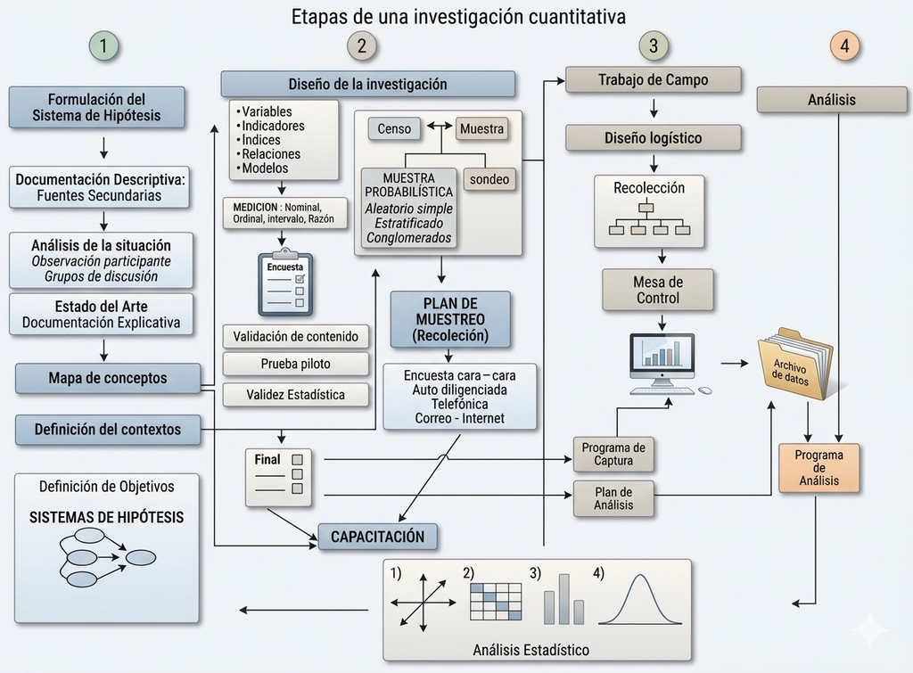

## Estrategia de muestreo

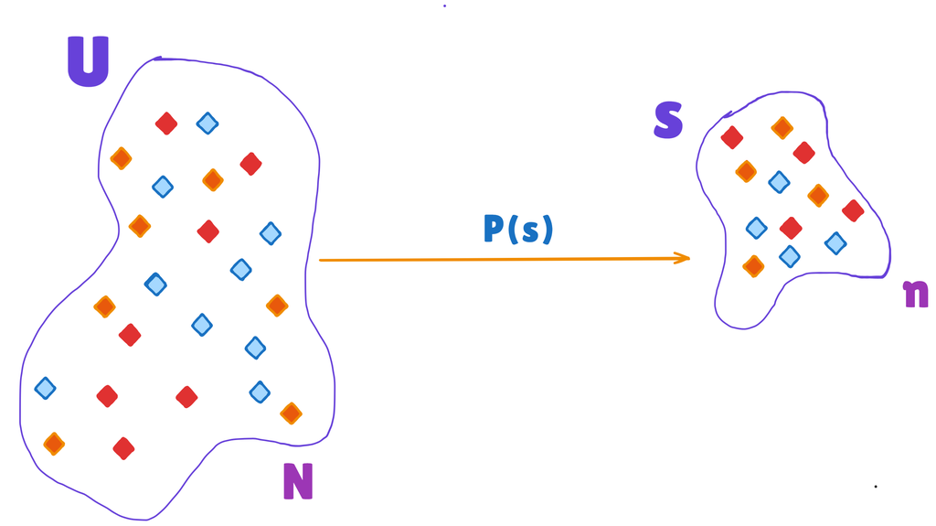

## Discusión

Discutamos los siguientes conceptos por 5 minutos:

- Aleatoriedad
- Variable aleatoria
- Población
- Muestra
- Incertidumbre
- Confiabilidad

## Decisiones previas al muestreo

- Propósito del estudio
- Población de interés
- Disponibilidad de bases de datos
- Instrumentos de medición
- Tipo de levantamiento de información
- Prueba piloto

## Conceptos básicos

**Universo ideal**: Se trata del conjunto sobre el cual el investigador y no propiamente el muestrista pretende obtener algún tipo de información. Definir Alcance: Ej. Intención de voto - ¿Rural?

**Población Objetivo**: Constituye el conjunto de elementos que partiendo del universo ideal pueden ser realmente alcanzados por la investigación. Lo anterior se puede dar por razones operativas, políticas, económicas, etc.

## Conceptos básicos

**Marco Muestral**: Dispositivo que permite **IDENTIFICAR y UBICAR** a todos los elementos de la población objetivo. Marcos de lista:

- Lista de estudiantes de esta clase.
- Lista de beneficiarios de un programa.
- Listado de municipios del país.

**TAREA**: Investigue qué es y cómo se obtiene el Marco Geoestadístico Nacional (MGN).

## Conceptos básicos

**Operación estadística**

Es la aplicación del conjunto de procesos y actividades que comprende la identificación de necesidades, diseño, construcción, recolección o acopio, procesamiento, análisis, difusión y evaluación, la cual conduce a la producción de información estadística sobre un tema de interés nacional o territorial.

**Unidades estadísticas**

Entidad acerca de la que se busca información y para la que se compilan las estadísticas. Puede dividirse en las siguientes categorías: unidad de observación, unidades de análisis y unidad de muestreo.

## Conceptos básicos

- **Muestra**: subconjunto de la población.
- **Unidad de muestreo**: objeto o elemento susceptible de ser seleccionado en la muestra.
- **Unidad de observación**: objeto sobre el cual se realiza al menos una medición.
- **Elemento**: unidad individual sobre la que se realizan mediciones.
- **Conglomerado**: agrupación de elementos.
- **Error de muestreo**: imputable a la aleatoriedad de la muestra.
- **Error de no muestreo**: se produce en toda la investigación por definiciones conceptuales incorrectas, fallos en los instrumentos de medida, en la entrevista o en el trabajo de campo.

## Definiciones: variables de interés

- ¿Qué es una variable?: $y_k$, $z_k$, $x_k$.
- Parámetros a investigar: totales, razones, proporciones, indicadores, índices. Por ejemplo: total de víctimas del conflicto armado, proporción de personas que votarán por determinado candidato, tasa de desempleo.

## Tu turno

Identifique:

- Universo
- Muestra
- Unidades estadísticas
- Variables
- Parámetros de interés

## Ejemplo 1: Clima escolar

La SED realizó una investigación en los colegios oficiales de la ciudad de Bogotá D.C. con el fin de medir el clima escolar de las instituciones, para ello usó una muestra de 658 sedes educativas, en las cuales se seleccionaron estudiantes de los grados 3°, 5°, 7° y 9° para aplicar un instrumento donde se indagan, entre otros, los aspectos sobre el bulling, habilidades socioemocionales, nivel de satisfacción con la sede educativa.

## Ejemplo 2: Intención de voto

Una campaña política para la Presidencia de la República realizó una investigación para establecer las estrategias a seguir. Para ello se dividió al país en 7 regiones, y dentro de cada una se dividieron los municipios en tres tipos: grandes, medianos y pequeños. Dentro de cada tipo se seleccionó una muestra de municipios, dentro de los municipios seleccionados se usó el MGN para seleccionar segmentos, hogares y finalmente personas. La muestra consideró a 6430 personas con edad para votar en 89 municipios, los cuales respondieron por el conocimiento de los candidatos, la intención de voto y los aspectos que consideran que actualmente son los principales problemas del país.

## Tipos de muestreo

Existen dos grandes categorías de métodos de muestreo.

Muestreo probabilístico. Todos los elementos de la población objetivo tienen una probabilidad **conocida** a priori de ser seleccionados, y al momento de la selección se aplica un algoritmo aleatorio que garantiza que dichas probabilidades se cumplan. Su fortaleza radica en la posibilidad de generalizar a toda la población; generalmente son muestras costosas.

Muestreo NO probabilístico. Todas las demás muestras, donde el investigador puede influenciar la selección, o donde —debido a la inexistencia de un marco muestral o a una población de difícil consecución— no es posible conocer las probabilidades a priori. No permite hacer inferencia hacia la población; es de bajo costo y fácil aplicación.

## Tipos de muestreo

Existen dos grandes categorías de métodos de muestreo

**Muestreo probabilístico:** Implica que todos los elementos de una población objetivo tienen una probabilidad CONOCIDA a priori de ser seleccionados y que al momento de la selección se aplica un algoritmo aleatorio que garantiza que dichas probabilidades se cumplan. Permite **generalizar los resultados a toda la población pero son costosos**

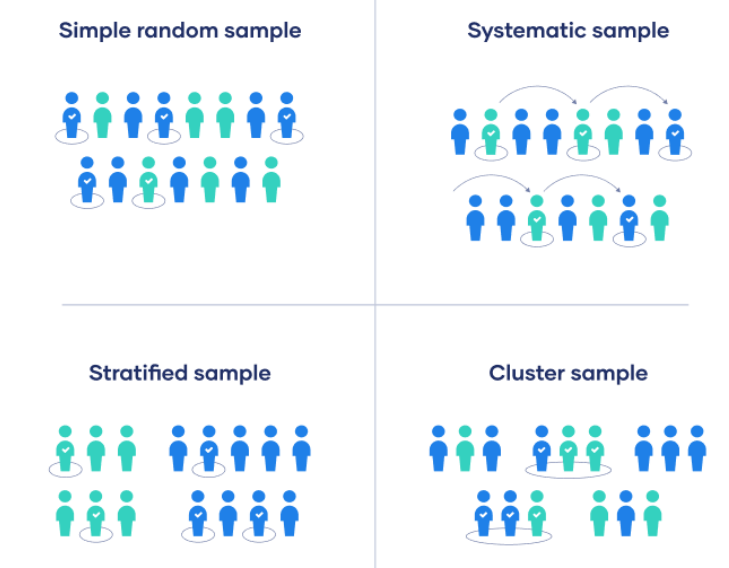

**Figura:** Fuente de la imagen: [Scribbr - Sampling Methods](https://www.scribbr.com/methodology/sampling-methods/)

## Tipos de muestreo

Existen dos grandes categorías de métodos de muestreo

**Muestreo NO probabilístico:** Son todas las demás muestras donde el investigador puede influenciar la selección o debido a la inexistencia de un marco muestral o por ser un target de difícil consecución no es posible conocer las probabilidades a priori. **No es posible hacer inferencia a la población**, es de bajo costo y fácil aplicación.

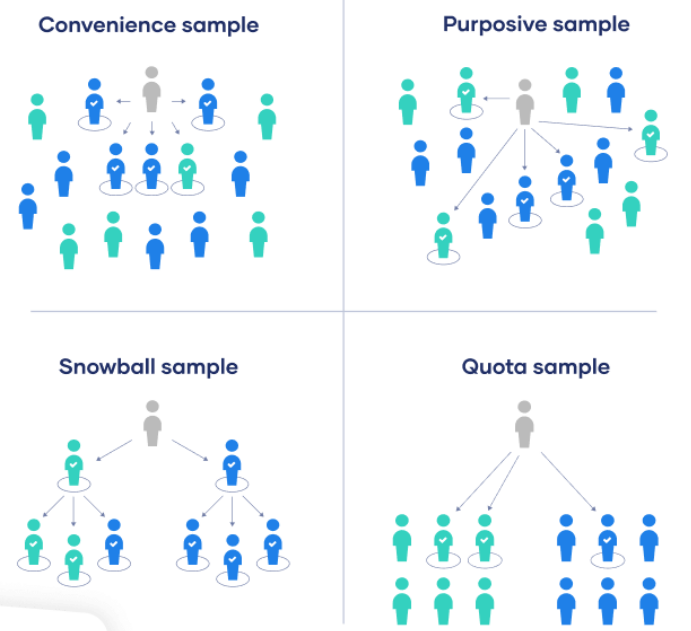

## Tipos de muestreo

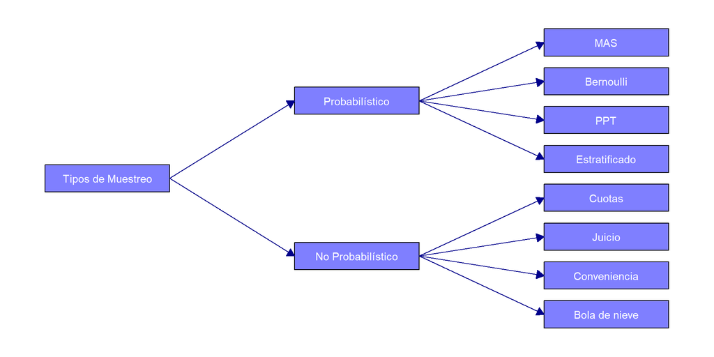

## Mecanismo de ponderación

Mecanismo utilizado para devolver a la muestra el peso diferencial que tiene en la población. Generalmente se usa para ajustar una distribución conocida a priori con la distribución observada a posteriori. Algunas se basan en:

- el diseño
- Posestratificación, *Raking*, GREG, etc.
- IPW, MI, DR.

¿Por cuáles variables pondero? La elección de las variables de ponderación es una decisión metodológica, no automática.

## Muestreo probabilístico: conceptos básicos

Sea $U$ un universo<sup>1</sup> de elementos $\{U_1,\ldots,U_N\}$ **finito** y **conocido** de antemano, con una variable de interés $Y$ que toma valores $\{y_1,\ldots,y_N\}$. Sea el parámetro $\theta$ (medida del universo) una función de $(y_1,\ldots,y_N)$; a $\theta(y_1,\ldots,y_N)$ se le denomina **parámetro** y se denota $\theta$.

[^1]: En adelante se denominará universo a la población objetivo.

## Muestreo probabilístico: ejemplos de parámetros

- **Total**: víctimas de ESCNNA, total de enfermos de COVID-19…
  $$t_y=\sum_U y_k$$
- **Promedio**: promedio de ingresos, promedio de ventas…
  $$\overline{y}_U=\frac{1}{N}\sum_U y_k$$
- **Razón**: personas ocupadas, hacinamiento, costos logísticos, consumo de gasolina de un auto (km por galón).
  $$R=\frac{\sum_U y_k}{\sum_U z_k}=\frac{t_y}{t_z}$$

## Muestreo probabilístico: conceptos básicos

Sea $s$ una muestra de elementos con mediciones $y_1,\ldots,y_{n_s}$. Se define el **estimador** $\widehat{\theta}$, una función de los valores de la muestra, buscada de tal manera que apunte al valor del parámetro $\theta$.

## Muestreo probabilístico: ejemplos de estimadores

- **Total**: víctimas de ESCNNA, total de enfermos de COVID-19.
  $$\widehat{t}_y = \, ?$$
- **Promedio**: promedio de ingresos, promedio de ventas…
  $$\overline{y}_s=\frac{1}{n_s}\sum_s y_k \qquad\qquad
  \widetilde{y}_s=\sqrt[n_s]{\prod_s y_k}$$

Note que la proporción, el promedio y la razón son casos particulares de la estimación de un **total**.

## Estimación por intervalo

Una vez hecha la estimación, la validez está dada por la estimación por intervalo.

Si $\widehat{\theta}$ es una función basada en una suma de variables aleatorias independientes, el Teorema Central del Límite permite encontrar una expresión para la estimación por intervalo bajo ciertas condiciones de regularidad. Si $\mathbb{E}(\widehat{\theta})=\theta$, se espera con una confiabilidad del $(1-\alpha)100\%$ que
$$\theta \in \left(\widehat{\theta}-z_{1-\alpha/2}\sqrt{V(\widehat{\theta})},\;
\widehat{\theta}+z_{1-\alpha/2}\sqrt{V(\widehat{\theta})}\right),$$
donde $z_{1-\alpha/2}$ es el percentil correspondiente de la distribución normal estándar.

## Observaciones

1. Lo que se distribuye normal es el **estadístico**, y no la variable de interés.
2. La distribución de la variable de interés es invariante, independientemente del tamaño de muestra.
3. Para estudios de tendencia no basta con comparar estimaciones puntuales: debe realizarse la prueba de hipótesis correspondiente para determinar si existe diferencia significativa (ejemplo: tasa de desempleo). Estos modelos deben incorporar el diseño.

## Teorema Central del Límite: método de Monte Carlo

Simule 100 muestras de tamaño $n$ provenientes de una distribución uniforme en $(0,1)$. Calcule el estadístico $\bar y_s$ para cada una de las 100 muestras y realice los histogramas para $n=5, 10, 15, 20, 25, 30, 40, 50, 60, 80, 100$. Concluya.

## Diseño muestral

Sea $s \subseteq U$ una muestra probabilística, y sea $S$ el conjunto de todas las muestras posibles. La función de medida de probabilidad
$$\mathbf{P}: S \rightarrow (0,1), \qquad s_i \mapsto p(s_i)$$
Dado el conjunto $S$, un **diseño de muestreo** es una función $p(\cdot)$ tal que $p(s_i)$ es la probabilidad de que la muestra $i$ sea seleccionada.

## Ejemplo: Muestreo Aleatorio Simple. $MAS(N,n)$

$$p(s_i)=\begin{cases}
\dfrac{1}{\binom{N}{n}} & \text{para toda muestra de tamaño } n \text{ de } N \text{ sin reposición} \\[4pt]
0 & \text{en otro caso}
\end{cases}$$

$n$ corresponde al tamaño de la muestra, mientras que $N$ corresponde al tamaño del universo.

## Mecanismo de selección

Algoritmo 1: coordinado negativo.

1. Generar $N$ realizaciones de una variable aleatoria $\xi_k$ ($k\in U$) con distribución uniforme (0,1).
2. Asignar $\xi_k$ al elemento $k$-ésimo de la población.
3. Ordenar la lista de elementos descendente (o ascendentemente) con respecto a este número aleatorio $\xi_k$.
4. A continuación, seleccionar los $n$ primeros (o los $n$ últimos) elementos. Esta selección corresponde a la muestra realizada.

Use la DIVIPOLA y seleccione 25 municipios usando un diseño MAS y el algoritmo coordinado negativo.

## Mecanismo de selección

Algoritmo 2: Fan, Muller & Rezucha (1962). Denominado método de selección-rechazo, consiste en ir descartando o seleccionando cada elemento de la muestra:

1. Realizar $\xi_k\sim U(0,1)$
2. Calcular
   $$\begin{equation*}
   c_k=\dfrac{n-n_k}{N-k+1}
   \end{equation*}$$
   donde $n_k$ es la cantidad de objetos seleccionados en los $k-1$ ensayos anteriores.
3. Si $\xi_k<c_k$, entonces el elemento $k$ pertenece a la muestra.
4. Detener el proceso cuando $n=n_k$.

Ejemplo en Excel: Fan-Muller.

Ejercicio: Use la DIVIPOLA para seleccionar una muestra de 25 municipios, use sample(N, n, replace = FALSE) y S.SI(N, n)

## Cierre

- Toda investigación por muestreo empieza por decisiones **conceptuales** (universo, marco, variables, objetivo) que anteceden cualquier fórmula.
- La estrategia muestral se divide en **probabilística** y **no probabilística**; solo la primera permite inferencia formal.
- Un diseño muestral es, formalmente, una función de probabilidad $p(\cdot)$ sobre el conjunto de todas las muestras posibles de $U$.

**Próxima sesión:** probabilidades de inclusión, la indicadora $I_k$, el $\pi$-estimador de Horvitz-Thompson y sus propiedades (Särndal, Cap. 2).

[figure not shown]

**Muestreo Estadístico** — Universidad Nacional de Colombia

© 2026 Giovany Babativa-Márquez, PhD. Todos los derechos reservados.

Material elaborado con fines académicos para el curso de Muestreo Estadístico. Se basa principalmente en Särndal, C.-E., Swensson, B. & Wretman, J. (1992). *Model Assisted Survey Sampling*. Springer. Prohibida su reproducción total o parcial con fines comerciales sin autorización expresa del autor.